# Rasiulyte_Assign3

## Project: Predicting Suicide Rates with Machine Learning

Task: Utilizing the "Suicide Rates Overview 1985 to 2016" dataset from Kaggle, I embarked on an exploration and modeling journey to predict suicide rates. The dataset boasts 12 unique features with a robust collection of 27,820 data points. My primary goal was to construct an insightful machine learning model that can categorize the likelihood of suicide as either "low suicide rate" or "high suicide rate."

Big-picture question: What are the key factors (features) that contribute to a higher or lower suicide rate, and how accurately we can predict whether a person has a high or low suicide rate based on those factors? Next step to identify these factors as part of feature selection.

```python
# Required Libraries
# Data manipulation and processing
import pandas as pd
import numpy as np

# Machine learning models and tools
from sklearn.model_selection import train_test_split
from sklearn.linear_model import LogisticRegression
from sklearn.ensemble import RandomForestClassifier, GradientBoostingClassifier
from sklearn.svm import SVC
from sklearn.neural_network import MLPClassifier
from sklearn.cluster import KMeans
from sklearn.preprocessing import LabelEncoder
from sklearn.metrics import accuracy_score
import xgboost as xgb

# Data visualization tools
import matplotlib.pyplot as plt
import seaborn as sns

# Miscellaneous
import warnings
```

Code below represents the preliminary exploration phase, highlighting data quality (missing values) and initial relationships between features (correlation heatmap).

```
<class 'pandas.core.frame.DataFrame'>
RangeIndex: 27820 entries, 0 to 27819
Data columns (total 12 columns):
 #   Column              Non-Null Count  Dtype
---  ------              --------------  -----
 0   country             27820 non-null  object
 1   year                27820 non-null  int64
 2   sex                 27820 non-null  object
 3   age                 27820 non-null  object
 4   suicides_no         27820 non-null  int64
 5   population          27820 non-null  int64
 6   suicides/100k pop   27820 non-null  float64
 7   country-year        27820 non-null  object
 8   HDI for year        8364 non-null   float64
 9    gdp_for_year ($)   27820 non-null  object
 10  gdp_per_capita ($)  27820 non-null  int64
 11  generation          27820 non-null  object
dtypes: float64(2), int64(4), object(6)
memory usage: 2.5+ MB

Missing Values
country                   0
year                      0
sex                       0
age                       0
suicides_no               0
population                0
suicides/100k pop         0
country-year              0
HDI for year          19456
 gdp_for_year ($)         0
gdp_per_capita ($)        0
generation                0
dtype: int64
```

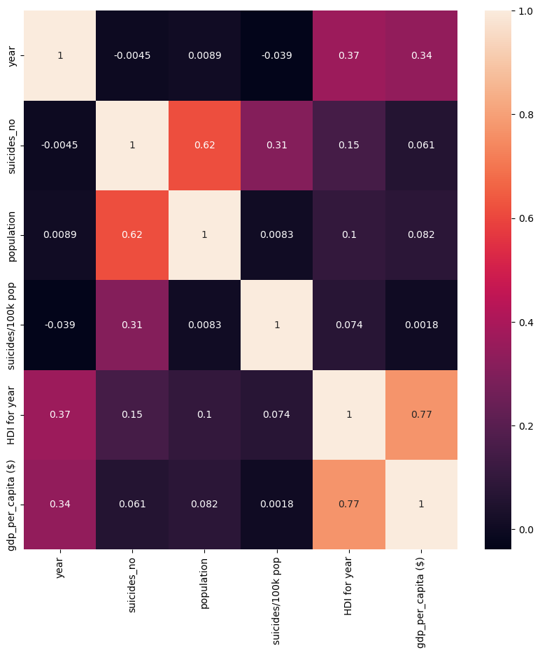

```python
# Disable warnings to have a cleaner output, especially useful when visualizing data
warnings.filterwarnings("ignore")

# Load the dataset
# Here, we use the pandas function 'read_csv' to read the CSV file named 'master.csv' into a DataFrame
df = pd.read_csv('master.csv')

# Displaying a concise summary of the dataset
# This includes index dtype, column dtypes, non-null values, and memory usage among other information
df.info()
print()  # Print an empty line for better output readability

# Checking for missing values in the dataset
# The 'isnull()' function returns a DataFrame of same shape containing True for NaN values and False for non-NaN values
# 'sum()' then aggregates the Trues for each column, giving the count of NaN values
missing_values = df.isnull().sum()

# Printing the number of missing values for each column
print('Missing Values')
print(missing_values)

# Visualize the data
# Examine the correlations between features using a heatmap
# A heatmap is useful to visualize the pairwise correlation of columns in the DataFrame

# Setting up the plot size
print()
plt.figure(figsize=(10,10))

# Using seaborn's 'heatmap' function to plot the correlations
# 'df.corr()' computes pairwise correlation of columns, excluding NA/null values
# 'annot=True' ensures the correlation values are plotted on the heatmap for clarity
sns.heatmap(df.corr(), annot=True)

# Display the plot
plt.show()
```

Upon examining the dataset, it's evident that the HDI_for_year column has 19,456 missing entries. Intriguingly, there seems to be a strong correlation between HDI_for_year and gdp_per_capita. To address these missing values, I'm contemplating employing predictive imputation.

Predictive Imputation Explained: Predictive imputation involves leveraging a predictive model to estimate and replace missing data points. In this context, our plan is to:

Utilize the gdp_per_capita as the independent variable. Treat HDI_for_year as the dependent variable. Train our model exclusively on rows where HDI_for_year has available data. Given the nature of the variables, a linear regression model seems fitting to predict and replace the missing HDI_for_year values based on gdp_per_capita.

However, an important caveat: this technique is underpinned by the assumption of a linear relationship between HDI_for_year and gdp_per_capita. This might not be universally accurate. While linear regression offers simplicity, more sophisticated models could potentially deliver more nuanced imputations, contingent on the dataset's intricacies.

Is the Relationship Linear? To ascertain whether HDI_for_year and gdp_per_capita truly share a linear relationship, let's employ a scatter plot for visualization. If our plotted data points gravitate towards a straight trajectory, it strengthens the case for a linear correlation between the two variables.

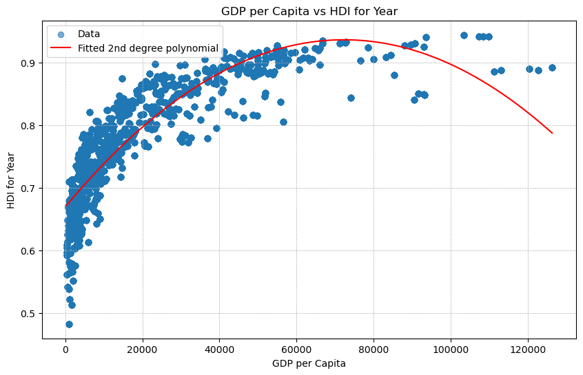

```python
# Assuming df is your original DataFrame
data_no_na = df.dropna(subset=['gdp_per_capita ($)', 'HDI for year'])

# Fit a 2nd degree polynomial to the data
coefficients = np.polyfit(data_no_na['gdp_per_capita ($)'], data_no_na['HDI for year'], 2)

# Create a range of x values for the fitted function with increased granularity
x_values = np.linspace(data_no_na['gdp_per_capita ($)'].min(), data_no_na['gdp_per_capita ($)'].max(), 500)

# Compute the corresponding y values
y_values = np.polyval(coefficients, x_values)

# Plot the data and the fitted function
plt.figure(figsize=(10, 6))
plt.scatter(data_no_na['gdp_per_capita ($)'], data_no_na['HDI for year'], label='Data', alpha=0.6)
plt.plot(x_values, y_values, color='red', label='Fitted 2nd degree polynomial')
plt.xlabel('GDP per Capita')
plt.ylabel('HDI for Year')
plt.title('GDP per Capita vs HDI for Year')
plt.legend()
plt.grid(True, which='both', linestyle='--', linewidth=0.5)
plt.show()
```

```python
# Using numpy's polyfit function to fit a 2nd-degree polynomial (quadratic) to the data
# This helps in understanding the relationship between 'gdp_per_capita ($)' and 'HDI for year'
# The function returns the coefficients [a, b, c] for the equation: ax^2 + bx + c
coefficients = np.polyfit(data_no_na['gdp_per_capita ($)'], data_no_na['HDI for year'], 2)

# Printing out the fitted function in the form of the equation
# This provides a human-readable representation of the relationship between the variables
print("Fitted function: f(x) = {0:.4f}x^2 + {1:.4f}x + {2:.4f}".format(coefficients[0], coefficients[1], coefficients[2]))
```

```
Fitted function: f(x) = -0.0000x^2 + 0.0000x + 0.6700
```

Note on Importance: Fitting a polynomial function, especially in this context, can help in better understanding and visualizing the relationship between GDP per capita and HDI for a year. If there's a non-linear correlation between these two variables, a quadratic function might offer a more accurate representation than a simple linear fit. By determining this function, we can make more nuanced predictions or inferences about the HDI based on GDP values. It's an essential step in the data exploration phase, allowing us to grasp the underlying dynamics of the dataset.

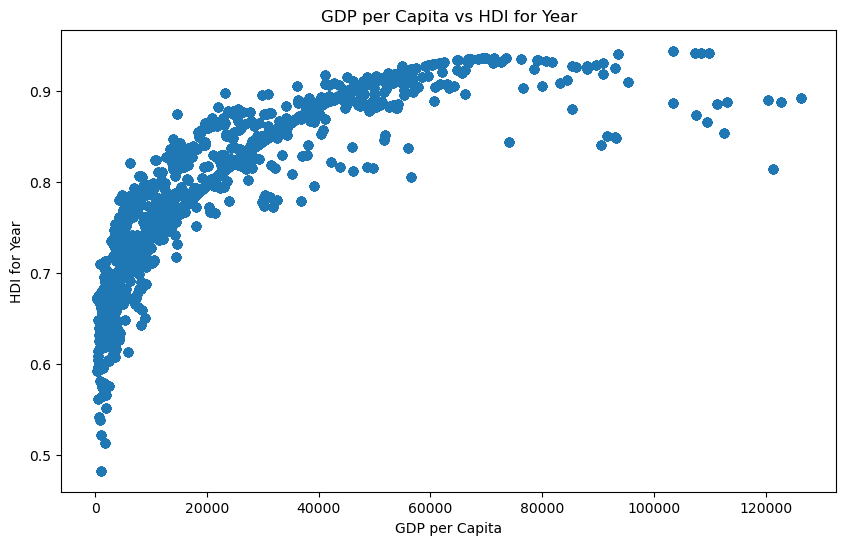

```
country               0
year                  0
sex                   0
age                   0
suicides_no           0
population            0
suicides/100k pop     0
country-year          0
HDI for year          0
 gdp_for_year ($)     0
gdp_per_capita ($)    0
generation            0
dtype: int64
```

```python
# Using numpy's polyfit function to fit a 2nd-degree polynomial (quadratic)
# to the data between 'gdp_per_capita ($)' and 'HDI for year'. This provides
# coefficients for the equation: ax^2 + bx + c
coefficients = np.polyfit(data_no_na['gdp_per_capita ($)'], data_no_na['HDI for year'], 2)

# Define a function using the derived coefficients to predict 'HDI for year' based on a given GDP
def predict_hdi(gdp):
    return coefficients[0]*gdp**2 + coefficients[1]*gdp + coefficients[2]

# For rows where 'HDI for year' is missing, predict and replace those missing values
# using the above-defined function and the 'gdp_per_capita ($)' value of that row
df.loc[df['HDI for year'].isna(), 'HDI for year'] = df.loc[df['HDI for year'].isna(), 'gdp_per_capita ($)'].apply(predict_hdi)

# Removing rows with missing values in either 'HDI for year' or 'gdp_per_capita ($)' columns
# for the purpose of accurate plotting
data_no_na = df.dropna(subset=['HDI for year', 'gdp_per_capita ($)'])

# Setting up the canvas for the scatter plot with a size of 10x6
plt.figure(figsize=(10, 6))

# Creating the scatter plot using matplotlib
plt.scatter(data_no_na['gdp_per_capita ($)'], data_no_na['HDI for year'])
plt.xlabel('GDP per Capita')
plt.ylabel('HDI for Year')
plt.title('GDP per Capita vs HDI for Year')

# Displaying the scatter plot
plt.show()

# Saving the DataFrame with the imputed 'HDI for year' values into a new CSV file
# named 'master_udpatedHDI.csv' without including the DataFrame's index
df.to_csv('master_udpatedHDI.csv', index=False)

# Verification step
# Loading the saved CSV file into a new DataFrame
updatedHDI_df = pd.read_csv('master_udpatedHDI.csv')

# Counting and printing the number of missing values in each column to verify
# that the 'HDI for year' column has been successfully imputed
missing_values = updatedHDI_df.isnull().sum()
print(missing_values)
```

Now we have updated dataset master_updatedHDI.csv Next step is to explore other interesting correliations that relates to suicide rate.

```
country                object
year                    int64
sex                    object
age                    object
suicides_no             int64
population              int64
suicides/100k pop     float64
country-year           object
HDI for year          float64
 gdp_for_year ($)      object
gdp_per_capita ($)      int64
generation             object
dtype: object
```

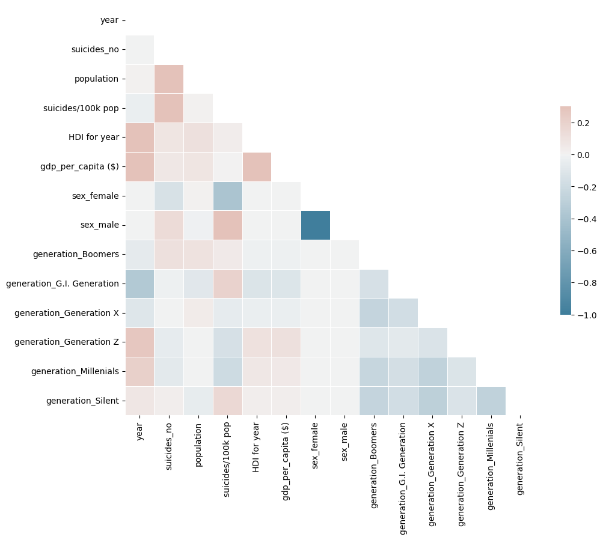

```python
# Print the data types of each column in the DataFrame 'updatedHDI_df'
# This helps identify which columns are categorical, numeric, etc.
print(updatedHDI_df.dtypes)

# One-hot encoding is used to convert categorical variables into a form that could be
# provided to ML algorithms to do a better job in prediction.
# Here, we're one-hot encoding the 'sex' and 'generation' columns of the DataFrame.
# This means each unique value in these columns becomes a new column itself and
# the values are replaced by 1 or 0 indicating the presence of that feature.
nominal_features = ['sex','generation']
updatedHDI_df = pd.get_dummies(updatedHDI_df, columns=nominal_features)

# Calculate the correlation matrix of the updated DataFrame.
# This matrix provides the correlation coefficients between every pair of columns in the DataFrame.
# Correlation coefficients range from -1 to 1, with -1 indicating a perfect inverse relationship,
# 1 indicating a perfect direct relationship, and 0 indicating no relationship.
corr = updatedHDI_df.corr()

# Create a boolean mask for the upper triangle of the matrix.
# This is because the correlation matrix is symmetric and we don't need to display both halves.
mask = np.triu(np.ones_like(corr, dtype=bool))

# Initialize a matplotlib figure with a specific size
f, ax = plt.subplots(figsize=(11, 9))

# Create a custom color map for the heatmap. Here, it's a diverging palette, which means
# values around the midpoint will have a distinct color from the extremes.
cmap = sns.diverging_palette(230, 20, as_cmap=True)

# Draw the heatmap using seaborn. The heatmap provides a color-coded representation of
# the correlation matrix. Darker colors represent higher correlations.
# The mask ensures we only show one half of the correlations.
# 'vmax' sets the colorbar's maximum saturation value.
# 'center' sets the value at which the colormap's center is set.
# 'cbar_kws' is for additional keyword arguments for the colorbar.
sns.heatmap(corr, mask=mask, cmap=cmap, vmax=.3, center=0,
            square=True, linewidths=.5, cbar_kws={"shrink": .5})

# Display the heatmap
plt.show()
```

By generating this heatmap, you visually represent how different variables in your dataset relate to each other. This is useful for identifying patterns, especially for large datasets where spotting relationships might be challenging by just looking at the numbers.

```python
# Calculate the average suicide rate for each country using the 'groupby' method.
# This groups the dataframe by the 'country' column and then calculates the mean of
# 'suicides/100k pop' for each country.
avg_suicide_rate = updatedHDI_df.groupby('country')['suicides/100k pop'].mean()

# To determine a threshold for what constitutes a "high risk" country, we use the average of
# the calculated average suicide rates of all countries.
threshold = avg_suicide_rate.mean()

# Using this threshold, we classify countries into two categories:
# 1. High-risk countries: Countries with an average suicide rate greater than the overall threshold.
# 2. Low-risk countries: Countries with an average suicide rate less than or equal to the threshold.
high_risk_countries = avg_suicide_rate[avg_suicide_rate > threshold].index.tolist()
low_risk_countries = avg_suicide_rate[avg_suicide_rate <= threshold].index.tolist()

# Finally, the lists of high and low-risk countries are printed out.
print("High-risk countries:")
print(high_risk_countries)
print()
print("Low-risk countries:")
print(low_risk_countries)
```

[output not shown]

In this analysis, countries with an average suicide rate above the global average are classified as high-risk, and those below it are classified as low-risk. This provides a clear division for interpretation and can be used for further studies, decisions, or interventions targeted at high-risk countries.

This code segment aims to cluster the high-risk countries based on their suicide rates and GDP per capita. The goal is to identify patterns among high-risk countries in relation to their economic status and suicide rates.

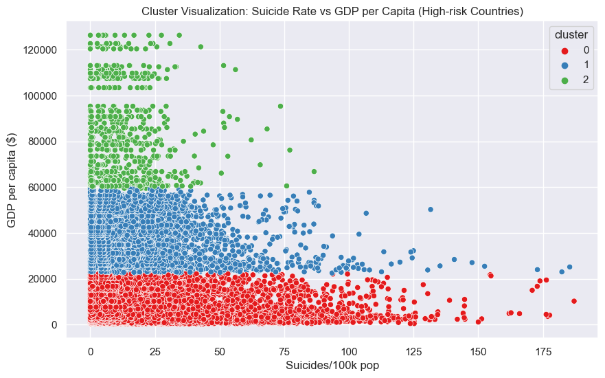

```
Cluster 0: 7752 countries
Cluster 1: 4436 countries
Cluster 2: 766 countries
```

```python
# Calculate the average suicide rate for each country using the 'groupby' method.
avg_suicide_rate = updatedHDI_df.groupby('country')['suicides/100k pop'].mean()

# Use the overall average of these rates to define a threshold for high-risk countries.
threshold = avg_suicide_rate.mean()

# Countries above this threshold are classified as "high risk".
high_risk_countries = avg_suicide_rate[avg_suicide_rate > threshold].index.tolist()

# From the main dataframe, extract only rows corresponding to high-risk countries.
high_risk_data = updatedHDI_df[updatedHDI_df['country'].isin(high_risk_countries)]

# For clustering, we'll consider two features: suicide rate and GDP per capita.
data = high_risk_data[['country', 'suicides/100k pop', 'gdp_per_capita ($)']]

# Remove any missing values to ensure clustering algorithm works without issues.
data = data.dropna()

# Prepare the data for clustering. Extract only the numerical columns for clustering.
X = data[['suicides/100k pop', 'gdp_per_capita ($)']].values

# Use the KMeans clustering algorithm to divide the countries into 3 clusters.
kmeans = KMeans(n_clusters=3, random_state=42)
kmeans.fit(X)

# Add a new column to our dataset indicating the cluster each country belongs to.
data['cluster'] = kmeans.labels_

# Use seaborn to create a scatter plot visualizing the clusters.
sns.set(style='darkgrid')
plt.figure(figsize=(10, 6))
sns.scatterplot(data=data, x='suicides/100k pop', y='gdp_per_capita ($)', hue='cluster', palette='Set1')
plt.xlabel('Suicides/100k pop')
plt.ylabel('GDP per capita ($)')
plt.title('Cluster Visualization: Suicide Rate vs GDP per Capita (High-risk Countries)')
plt.show()

# Calculate and print the number of countries in each cluster.
cluster_counts = data['cluster'].value_counts()
for cluster, count in cluster_counts.items():
    print(f"Cluster {cluster}: {count} countries")
```

This clustering can provide insightful information on how countries with high suicide rates cluster in terms of their economic status. This kind of analysis can help policymakers understand if there are any discernible patterns or groupings among high-risk countries based on their economic and social parameters.

Conclusion: for high risk countries, the higher rate of suicides shows up in countries with lower GDP per capital (under 60000)

The below code performs clustering on the countries classified as "low-risk" based on their suicide rates and GDP per capita. The goal of this segment is similar to the previous one for high-risk countries but focuses on low-risk countries to uncover any potential patterns or groupings among them.

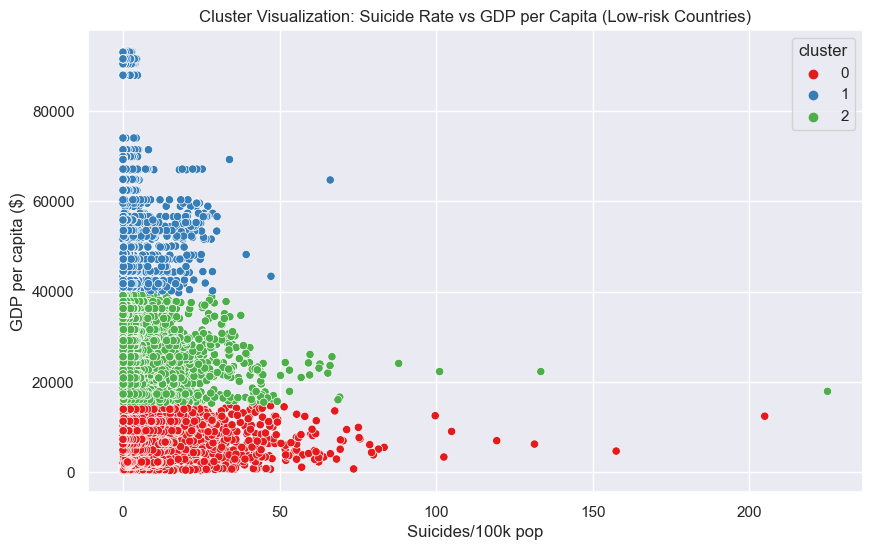

```
Cluster 0: 10852 countries
Cluster 2: 3202 countries
Cluster 1: 812 countries
```

```python
# Calculate the average suicide rate for each country
avg_suicide_rate = updatedHDI_df.groupby('country')['suicides/100k pop'].mean()

# Calculate the overall average of these rates to set a threshold for low-risk countries.
threshold = avg_suicide_rate.mean()

# Classify countries below this threshold as "low risk".
low_risk_countries = avg_suicide_rate[avg_suicide_rate < threshold].index.tolist()

# From the main dataframe, select only rows corresponding to these low-risk countries.
low_risk_data = updatedHDI_df[updatedHDI_df['country'].isin(low_risk_countries)]

# For clustering, we'll consider two features: suicide rate and GDP per capita.
data = low_risk_data[['country', 'suicides/100k pop', 'gdp_per_capita ($)']]

# Drop any missing values to ensure the clustering algorithm operates smoothly.
data = data.dropna()

# Prepare the data for clustering by extracting the required numerical columns.
X = data[['suicides/100k pop', 'gdp_per_capita ($)']].values

# Implement the KMeans clustering algorithm to segregate the countries into 3 clusters.
kmeans = KMeans(n_clusters=3, random_state=42)
kmeans.fit(X)

# Append a new column in our dataset indicating the cluster each country falls into.
data['cluster'] = kmeans.labels_

# Use seaborn to create a scatter plot visualizing these clusters.
sns.set(style='darkgrid')
plt.figure(figsize=(10, 6))
sns.scatterplot(data=data, x='suicides/100k pop', y='gdp_per_capita ($)', hue='cluster', palette='Set1')
plt.xlabel('Suicides/100k pop')
plt.ylabel('GDP per capita ($)')
plt.title('Cluster Visualization: Suicide Rate vs GDP per Capita (Low-risk Countries)')
plt.show()

# Compute and showcase the number of countries in each cluster.
cluster_counts = data['cluster'].value_counts()
for cluster, count in cluster_counts.items():
    print(f"Cluster {cluster}: {count} countries")
```

Conclusion: for lower risk countries, higher rate of suicides seem to be associated with lower GDP per capita (under 40000)

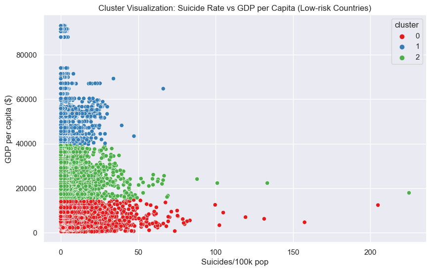

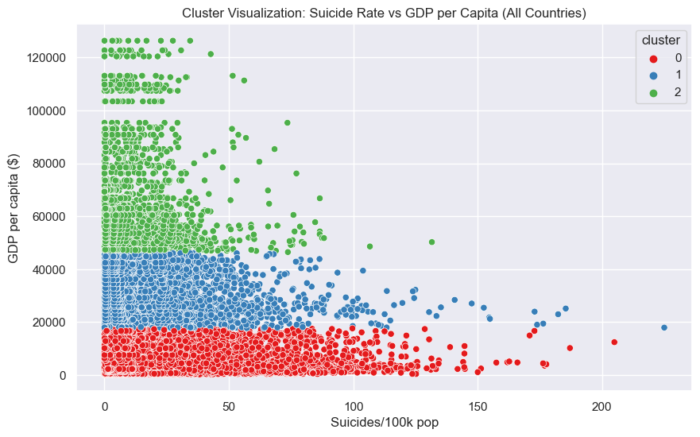

```
Cluster 0: 18390 countries
Cluster 1: 7052 countries
Cluster 2: 2378 countries
```

```python
# Assuming 'updatedHDI_df' is your main dataset

# Calculate the average suicide rate for each country
avg_suicide_rate = updatedHDI_df.groupby('country')['suicides/100k pop'].mean()

# Calculate the overall average of these rates to set a threshold for low-risk countries.
threshold = avg_suicide_rate.mean()

# Classify countries below this threshold as "low risk".
low_risk_countries = avg_suicide_rate[avg_suicide_rate < threshold].index.tolist()

# Filter data for low-risk countries and drop any missing values
low_risk_data = updatedHDI_df[updatedHDI_df['country'].isin(low_risk_countries)]
low_risk_data = low_risk_data[['country', 'suicides/100k pop', 'gdp_per_capita ($)']].dropna()

# Clustering for low-risk countries
X_low = low_risk_data[['suicides/100k pop', 'gdp_per_capita ($)']].values
kmeans_low = KMeans(n_clusters=3, random_state=42)
kmeans_low.fit(X_low)
low_risk_data['cluster'] = kmeans_low.labels_

# Visualize the clusters for low-risk countries
sns.set(style='darkgrid')
plt.figure(figsize=(10, 6))
sns.scatterplot(data=low_risk_data, x='suicides/100k pop', y='gdp_per_capita ($)', hue='cluster', palette='Set1')
plt.xlabel('Suicides/100k pop')
plt.ylabel('GDP per capita ($)')
plt.title('Cluster Visualization: Suicide Rate vs GDP per Capita (Low-risk Countries)')
plt.show()

# Clustering for all countries
all_data = updatedHDI_df[['country', 'suicides/100k pop', 'gdp_per_capita ($)']].dropna()
X_all = all_data[['suicides/100k pop', 'gdp_per_capita ($)']].values
kmeans_all = KMeans(n_clusters=3, random_state=42)
kmeans_all.fit(X_all)
all_data['cluster'] = kmeans_all.labels_

# Visualize the clusters for all countries
plt.figure(figsize=(10, 6))
sns.scatterplot(data=all_data, x='suicides/100k pop', y='gdp_per_capita ($)', hue='cluster', palette='Set1')
plt.xlabel('Suicides/100k pop')
plt.ylabel('GDP per capita ($)')
plt.title('Cluster Visualization: Suicide Rate vs GDP per Capita (All Countries)')
plt.show()

# Print the count of countries in each cluster for all countries
cluster_counts_all = all_data['cluster'].value_counts()
for cluster, count in cluster_counts_all.items():
    print(f"Cluster {cluster}: {count} countries")
```

CONCLUSION: overall higher rate of suicide in all countries is associated with lower GDP per capita (under 60000)

OVERALL CONCLUSIONS from exploring data:

High-risk countries: ['Australia', 'Austria', 'Belarus', 'Belgium', 'Bulgaria', 'Canada', 'Croatia', 'Cuba', 'Czech Republic', 'Denmark', 'Estonia', 'Finland', 'France', 'Germany', 'Guyana', 'Hungary', 'Iceland', 'Japan', 'Kazakhstan', 'Kyrgyzstan', 'Latvia', 'Lithuania', 'Luxembourg', 'Macau', 'Mongolia', 'New Zealand', 'Norway', 'Poland', 'Republic of Korea', 'Romania', 'Russian Federation', 'Serbia', 'Singapore', 'Slovakia', 'Slovenia', 'Sri Lanka', 'Suriname', 'Sweden', 'Switzerland', 'Trinidad and Tobago', 'Ukraine', 'United States', 'Uruguay']

High-risk gender: male

High-risk generations: G.I. Generation Silent Boomers

High-risk GDP per capita:

<60000

### Model Building

#### Logistic Regression vs. Random Forest Model Prototypes

```python
# Prepare your dataset by selecting the desired fields
updated_df = df[['country', 'sex', 'gdp_per_capita ($)', 'generation', 'suicides/100k pop']]

# Drop missing values if any
updated_df = updated_df.dropna()

# Convert the suicides/100k pop to a binary class based on a threshold
threshold = 25  # Set the threshold for classifying high or low risk
updated_df['risk_level'] = updated_df['suicides/100k pop'].apply(lambda x: 'High' if x > threshold else 'Low')

# Separate the features (X) and the target variable (y)
X = updated_df[['country', 'sex', 'gdp_per_capita ($)', 'generation']]
y = updated_df['risk_level']

# Perform one-hot encoding on categorical variables (country, sex, generation)
X = pd.get_dummies(X)

# Split the dataset into training and testing sets
X_train, X_test, y_train, y_test = train_test_split(X, y, test_size=0.1, stratify=y, random_state=42)

# Create a logistic regression model
logistic_model = LogisticRegression()

# Train the logistic regression model on the training set
logistic_model.fit(X_train, y_train)

# Make predictions using the logistic regression model
logistic_pred = logistic_model.predict(X_test)

# Evaluate the logistic regression model's performance
logistic_accuracy = accuracy_score(y_test, logistic_pred)
print(f"Logistic Regression Accuracy: {logistic_accuracy}")

# Create a random forest classifier model
random_forest_model = RandomForestClassifier()

# Train the random forest classifier model on the training set
random_forest_model.fit(X_train, y_train)

# Make predictions using the random forest classifier model
random_forest_pred = random_forest_model.predict(X_test)

# Evaluate the random forest classifier model's performance
random_forest_accuracy = accuracy_score(y_test, random_forest_pred)
print(f"Random Forest Accuracy: {random_forest_accuracy}")
```

```
Logistic Regression Accuracy: 0.8734723220704529
Random Forest Accuracy: 0.9281092739036664
```

#### Gradient Boosting Model Prototype

```python
# Prepare your dataset by selecting the desired fields
updated_df = df[['country', 'sex', 'gdp_per_capita ($)', 'generation', 'suicides/100k pop']]

# Drop missing values if any
updated_df = updated_df.dropna()

# Convert the suicides/100k pop to a binary class based on a threshold
threshold = 25  # Set the threshold for classifying high or low risk
updated_df['risk_level'] = updated_df['suicides/100k pop'].apply(lambda x: 'High' if x > threshold else 'Low')

# Separate the features (X) and the target variable (y)
X = updated_df[['country', 'sex', 'gdp_per_capita ($)', 'generation']]
y = updated_df['risk_level']

# Perform one-hot encoding on categorical variables (country, sex, generation)
X = pd.get_dummies(X)

# Split the dataset into training and testing sets
X_train, X_test, y_train, y_test = train_test_split(X, y, test_size=0.1, stratify=y, random_state=42)

# Create a gradient boosting classifier model
gb_model = GradientBoostingClassifier()

# Train the gradient boosting classifier model on the training set
gb_model.fit(X_train, y_train)

# Make predictions using the gradient boosting classifier model
gb_pred = gb_model.predict(X_test)

# Evaluate the gradient boosting classifier model's performance
gb_accuracy = accuracy_score(y_test, gb_pred)
print(f"Gradient Boosting Accuracy: {gb_accuracy}")
```

```
Gradient Boosting Accuracy: 0.8975557153127247
```

#### SVM Prototype

```python
# Prepare your dataset by selecting the desired fields
updated_df = df[['country', 'sex', 'gdp_per_capita ($)', 'generation', 'suicides/100k pop']]

# Drop missing values if any
updated_df = updated_df.dropna()

# Convert the suicides/100k pop to a binary class based on a threshold
threshold = 25  # Set the threshold for classifying high or low risk
updated_df['risk_level'] = updated_df['suicides/100k pop'].apply(lambda x: 'High' if x > threshold else 'Low')

# Separate the features (X) and the target variable (y)
X = updated_df[['country', 'sex', 'gdp_per_capita ($)', 'generation']]
y = updated_df['risk_level']

# Perform one-hot encoding on categorical variables (country, sex, generation)
X = pd.get_dummies(X)

# Split the dataset into training and testing sets
X_train, X_test, y_train, y_test = train_test_split(X, y, test_size=0.1, stratify=y, random_state=42)

# Create an SVM classifier model
svm_model = SVC()

# Train the SVM classifier model on the training set
svm_model.fit(X_train, y_train)

# Make predictions using the SVM classifier model
svm_pred = svm_model.predict(X_test)

# Evaluate the SVM classifier model's performance
svm_accuracy = accuracy_score(y_test, svm_pred)
print(f"SVM Accuracy: {svm_accuracy}")
```

```
SVM Accuracy: 0.8457943925233645
```

#### MLP Prototype

```python
# Prepare your dataset by selecting the desired fields
updated_df = df[['country', 'sex', 'gdp_per_capita ($)', 'generation', 'suicides/100k pop']]

# Drop missing values if any
updated_df = updated_df.dropna()

# Convert the suicides/100k pop to a binary class based on a threshold
threshold = 25  # Set the threshold for classifying high or low risk
updated_df['risk_level'] = updated_df['suicides/100k pop'].apply(lambda x: 'High' if x > threshold else 'Low')

# Separate the features (X) and the target variable (y)
X = updated_df[['country', 'sex', 'gdp_per_capita ($)', 'generation']]
y = updated_df['risk_level']

# Perform one-hot encoding on categorical variables (country, sex, generation)
X = pd.get_dummies(X)

# Split the dataset into training and testing sets
X_train, X_test, y_train, y_test = train_test_split(X, y, test_size=0.1, stratify=y, random_state=42)

# Create an MLP classifier model
mlp_model = MLPClassifier()

# Train the MLP classifier model on the training set
mlp_model.fit(X_train, y_train)

# Make predictions using the MLP classifier model
mlp_pred = mlp_model.predict(X_test)

# Evaluate the MLP classifier model's performance
mlp_accuracy = accuracy_score(y_test, mlp_pred)
print(f"Neural Network (MLP) Accuracy: {mlp_accuracy}")
```

```
Neural Network (MLP) Accuracy: 0.8684399712437095
```

#### XGBoost Model Prototype

```python
# Prepare your dataset by selecting the desired fields
updated_df = df[['country', 'sex', 'gdp_per_capita ($)', 'generation', 'suicides/100k pop']]

# Drop missing values if any
updated_df = updated_df.dropna()

# Convert the suicides/100k pop to a binary class based on a threshold
threshold = 25  # Set the threshold for classifying high or low risk
updated_df['risk_level'] = updated_df['suicides/100k pop'].apply(lambda x: 'High' if x > threshold else 'Low')

# Separate the features (X) and the target variable (y)
X = updated_df[['country', 'sex', 'gdp_per_capita ($)', 'generation']]
y = updated_df['risk_level']

# Perform one-hot encoding on categorical variables (country, sex, generation)
X = pd.get_dummies(X)

# Encode the target variable
label_encoder = LabelEncoder()
y = label_encoder.fit_transform(y)

# Split the dataset into training and testing sets
X_train, X_test, y_train, y_test = train_test_split(X, y, test_size=0.1, stratify=y, random_state=42)

# Create an XGBoost classifier model
xgb_model = xgb.XGBClassifier()

# Train the XGBoost classifier model on the training set
xgb_model.fit(X_train, y_train)

# Make predictions using the XGBoost classifier model
xgb_pred = xgb_model.predict(X_test)

# Evaluate the XGBoost classifier model's performance
accuracy = accuracy_score(y_test, xgb_pred)
print(f"XGBoost Accuracy: {accuracy}")
```

```
XGBoost Accuracy: 0.9313443565780014
```

### Overview of the Project

Objective: The primary goal of this project was to assess and predict the risk level of suicides based on certain determinants, including country demographics, GDP per capita, and generation type.

Technologies Used: Python: Chosen for its versatility and extensive libraries that are essential for data processing and machine learning.

Pandas: Utilized for data wrangling, preprocessing, and one-hot encoding of categorical variables.

Scikit-learn: The backbone of the project for model creation, training, and testing. It provides various algorithms and tools necessary for predictive modeling.

XGBoost: A highly efficient gradient boosting framework that was used because of its performance advantages and fine-tuning capabilities.

NumPy: Leveraged for numerical computations, especially during data visualization.

Matplotlib: Used for visualizing the relationship between GDP per capita and HDI for a year with a polynomial fit.

#### Model Performances:

The models were gauged based on their accuracy, and their performance is ranked as follows:

Logistic Regression: 87.35% - A simple yet effective algorithm for binary classification problems.

SVM: 84.58% - Effective in high-dimensional spaces and situations where the boundary between classes is clear.

#### Conclusion:

The project effectively utilized various machine learning algorithms to predict suicide risk levels based on the provided data. Among all, XGBoost performed the best, closely followed by Random Forest. The insights derived from this project can be crucial for policymakers, researchers, and clinicians in understanding and devising strategies to mitigate suicide risks.